# Reproducible Research Project 1

Barnabas Jenkins Kollie

2025-06-11

#Loading Libraries

```r
library(lubridate)
library(dplyr)
library(tibble)
library(lattice)
```

#loading the dataset

```r
activity <- read.csv("activity.csv")
str(activity)
```

```
## 'data.frame':    17568 obs. of  3 variables:
##  $ steps   : int  NA NA NA NA NA NA NA NA NA NA ...
##  $ date    : chr  "2012-10-01" "2012-10-01" "2012-10-01" "2012-10-01" ...
##  $ interval: int  0 5 10 15 20 25 30 35 40 45 ...
```

What is mean total number of steps taken per day? 1. Calculate the total number of steps taken per day

```r
Steps_total_per_day <- aggregate(steps~date, activity, sum)
head(Steps_total_per_day)
```

```
##         date steps
## 1 2012-10-02   126
## 2 2012-10-03 11352
## 3 2012-10-04 12116
## 4 2012-10-05 13294
## 5 2012-10-06 15420
## 6 2012-10-07 11015
```

```r
mean_per_day <- aggregate(steps~date, activity, mean)
head(mean_per_day, 10)
```

```
##          date    steps
## 1  2012-10-02  0.43750
## 2  2012-10-03 39.41667
## 3  2012-10-04 42.06944
## 4  2012-10-05 46.15972
## 5  2012-10-06 53.54167
## 6  2012-10-07 38.24653
## 7  2012-10-09 44.48264
## 8  2012-10-10 34.37500
## 9  2012-10-11 35.77778
## 10 2012-10-12 60.35417
```

2. Make a histogram of the total number of steps taken each day

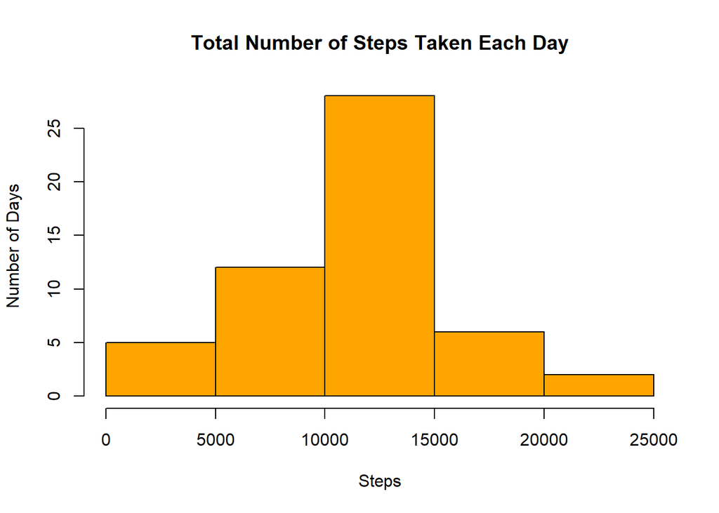

```r
hist(Steps_total_per_day$steps,
     col = "orange",
     main = "Total Number of Steps Taken Each Day",
     xlab =  "Steps",
     ylab = "Number of Days")
```

3. Calculate and report the mean and median of the total number of steps taken per day

3a. mean calculation

```r
mean_of_steps <- mean(Steps_total_per_day$steps)
print(mean_of_steps)
```

```
## [1] 10766.19
```

3b. median calculation

```r
median_steps <- median(Steps_total_per_day$steps)
print(median_steps)
```

```
## [1] 10765
```

What is the average daily activity pattern?

Make a time series plot (type = “l”) of the 5-minute interval (x-axis) and the average number of steps taken, averaged across all days (y-axis) 1.1 The average number of steps taken & Time series plot:

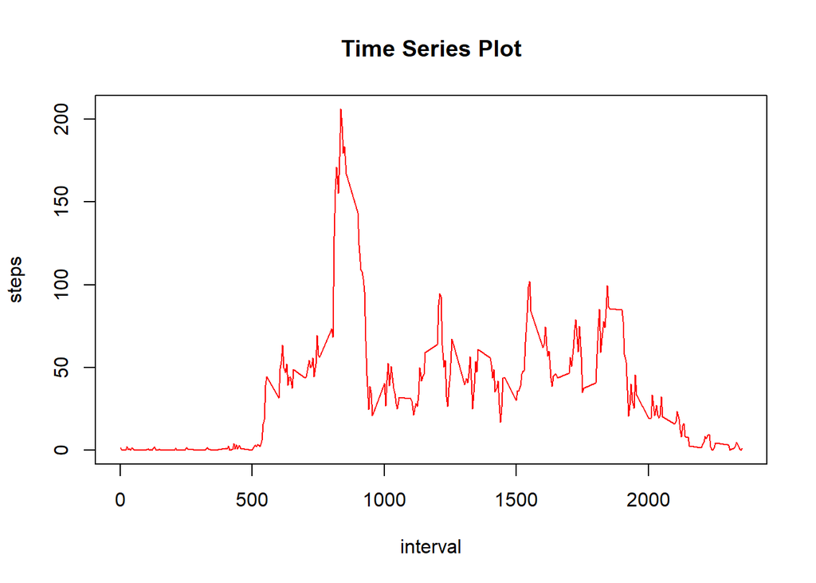

```r
average_steps <- aggregate(steps~interval, activity, mean)
with(average_steps,
     plot(interval,
          steps,
          type = "l",
          col= "red",
          main = "Time Series Plot"))
```

2. Which 5-minute interval, on average across all the days in the dataset, contains the maximum number of steps?

```r
interval_max <- average_steps[which.max(average_steps$steps),1]
print(interval_max)
```

```
## [1] 835
```

Inputing missing values Calculate and report the total number of missing values in the dataset (i.e. the total number of rows with NAs)

```r
missing_values <- sum(is.na(activity$steps))
print(missing_values)
```

```
## [1] 2304
```

Answer 1: The total number of rows with NAs is 2304)

```r
mean_values <- mean(average_steps$steps)
print(mean_values)
```

```
## [1] 37.3826
```

Create a new dataset that is equal to the original dataset but with the missing data filled in. 3.1 Create a new dataset

```r
new_df <- activity
```

3.2 Fill the new_df with mean values (37.3826)

```r
new_df[is.na(new_df)] <- mean_values
head(new_df)
```

```
##     steps       date interval
## 1 37.3826 2012-10-01        0
## 2 37.3826 2012-10-01        5
## 3 37.3826 2012-10-01       10
## 4 37.3826 2012-10-01       15
## 5 37.3826 2012-10-01       20
## 6 37.3826 2012-10-01       25
```

Make a histogram of the total number of steps taken each day and Calculate and report the mean and median total number of steps taken per day.

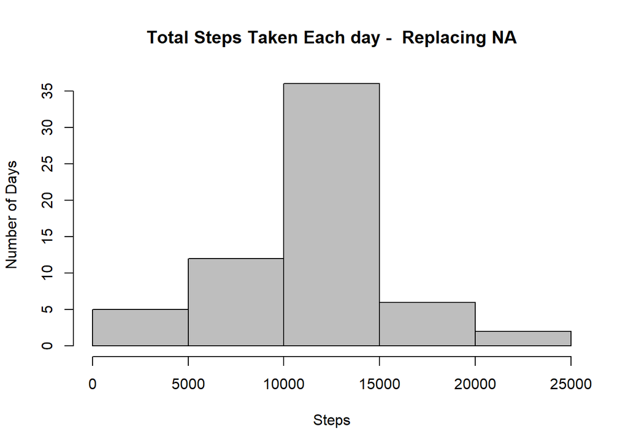

```r
totalstepsnew_df <- aggregate(steps ~ date, new_df, sum)
hist(totalstepsnew_df$steps,
     main = "Total Steps Taken Each day -  Replacing NA",
     ylab = "Number of Days",
     xlab = "Steps",
     col = "gray")
```

4.1 Calculate mean

```r
mean_steps_new_df <- mean(totalstepsnew_df$steps)
head(mean_steps_new_df)
```

```
## [1] 10766.19
```

4.2 Calulate median

```r
median_steps_new_df <- median(totalstepsnew_df$steps)
print(median_steps_new_df)
```

```
## [1] 10766.19
```

Do these values differ from # the estimates from the first part of the assignment? There is insignificant difference. When I was replacing the NA values I got an increase about number of days but insignificant difference between previous values of mean and median

What is the impact of inputing missing data on the estimates of the total daily number of steps? The number of days increased.

Are there differences in activity patterns between weekdays and weekends? For this part the weekdays() function may be of some help here. Use the dataset with the filled-in missing values for this part.

Create a new factor variable in the dataset with two levels “weekday” and “weekend” indicating whether a given date is a weekday or weekend day.

```r
new_df$date <- as.Date(new_df$date)

df <- new_df %>%
    mutate(dayofweek = ifelse(weekdays(new_df$date) == "Saturday" | weekdays(new_df$date) == "Sunday","weekend","weekday"))
```

2. Make a panel plot containing a time series plot (i.e.type=“l”) of the 5-minute interval (x-axis) and the average number of steps taken, averaged across all weekday days or weekend days (y-axis)

```r
df2<-df %>%
    group_by(dayofweek, interval) %>%
    summarize(sumsteps=sum(steps))
```

display of the data table after summarization

```r
head(df2)
```

```
## # A tibble: 6 × 3
## # Groups:   dayofweek [1]
##   dayofweek interval sumsteps
##   <chr>        <int>    <dbl>
## 1 weekday          0     315.
## 2 weekday          5     242.
## 3 weekday         10     231.
## 4 weekday         15     232.
## 5 weekday         20     228.
## 6 weekday         25     283.
```

[figure not shown]

```r
with(df2,
     xyplot(sumsteps ~ interval | dayofweek,
            type = "l",
            main = "Total Number of Steps within Intervals by dayofweek",
            xlab = "Daily Intervals",
            ylab = "Average Number of Steps"))
```